# Growth Chamber 2026 - Soybean Limited-Transpiration Experiment

Transpiration and stomatal conductance response to VPD | Elli Lab, University of Arkansas | Report generated: 2026-08-05

## Overview

14

Genotypes

4

Replicates

6

VPD treatments

1.00-3.81

VPD range (kPa)

16.5-93.7

TR range (mg m⁻² s⁻¹)

253

Day-1 observations

Transpiration rate (TR) and stomatal conductance (g<sub>sw</sub>) responses to stepped VPD levels in 14 soybean genotypes across five WUE phenotype classes. Three model types fitted to Day-1 data and compared by AIC.

## Experimental design

### VPD treatments

Table 1. VPD treatments - targets and achieved values.

| Treatment | Temp (degC) | Target RH (%) | Target VPD (kPa) | Mean VPD (kPa) |
| --- | --- | --- | --- | --- |
| 1 | 32 | 79 | 1 | 1.003 |
| 2 | 32 | 68 | 1.52 | 1.517 |
| 3 | 32 | 57 | 2.04 | 2.056 |
| 4 | 32 | 47 | 2.52 | 2.502 |
| 5 | 32 | 37 | 3 | 3.024 |
| 6 | 32 | 24 | 3.61 | 3.666 |

### Genotypes

Table 2. Genotypes and WUE phenotype class.

| Genotype | WUE class |
| --- | --- |
| PI398198 | MAGIC parent |
| PI377574 | Nonplastic, Low WUE |
| PI398272 | Nonplastic, Low WUE |
| PI404191 | Nonplastic, Low WUE |
| PI603171 | Nonplastic, Low WUE |
| PI398492 | Plastic, High WUE |
| PI398617 | Plastic, High WUE |
| PI424231 | Plastic, High WUE |
| PI442012A | Plastic, High WUE |
| PI603418D | Plastic, High WUE |
| A5959 | high_wilting |
| AG43XF2 | high_wilting |
| PI416937 | slow_wilting |
| PI471938 | slow_wilting |

## Quality control

✓ No TR outliers detected (3×IQR rule within Genotype × Day × Treatment).

### QC1 - TR distribution

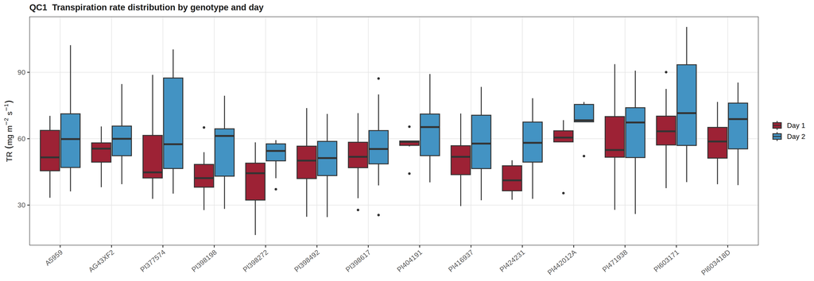

Fig. QC1. TR boxplots by genotype and day. No extreme outliers.

### QC2 - TR vs VPD (both days)

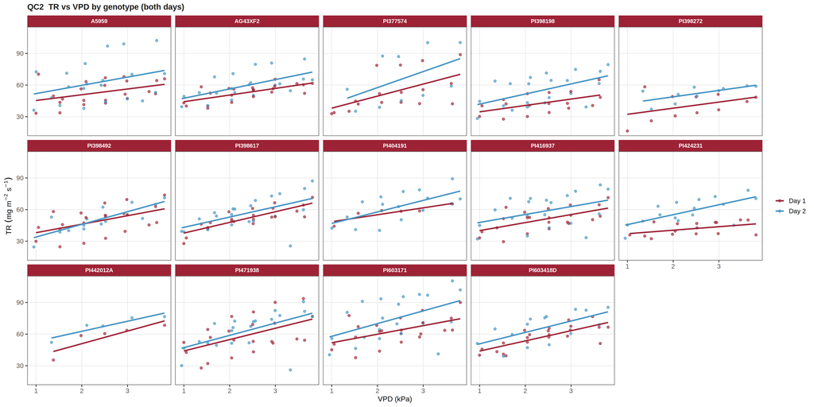

Fig. QC2. Raw TR vs VPD per genotype, OLS trend per day.

### QC4 - g<sub>sw</sub> distribution

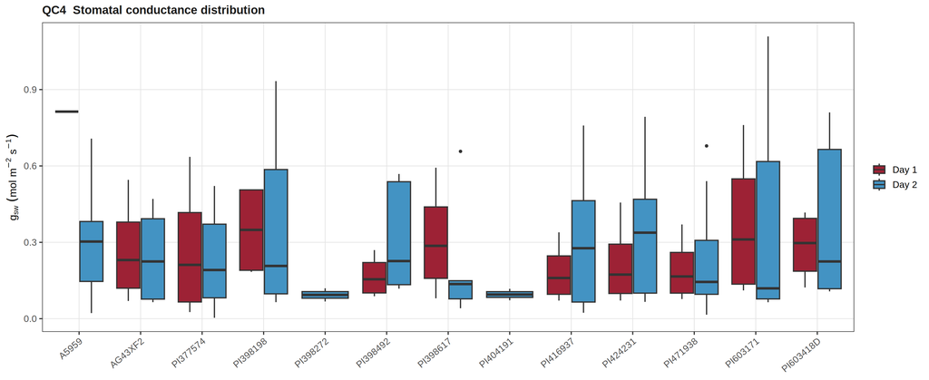

Fig. QC4. g<sub>sw</sub> distribution (LICOR data only).

### QC5 - g<sub>sw</sub> vs VPD, Day 1

[figure not shown]

Fig. QC5. Stomatal conductance vs VPD for genotypes with Day-1 LICOR data.

### QC6 - Leaf area by replicate

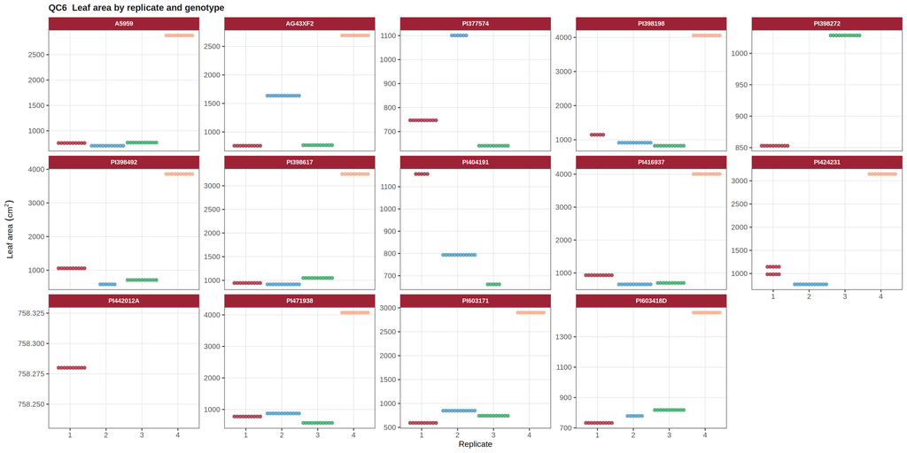

Fig. QC6. Leaf area (cm²) per replicate and genotype.

### QC7 - Chamber conditions

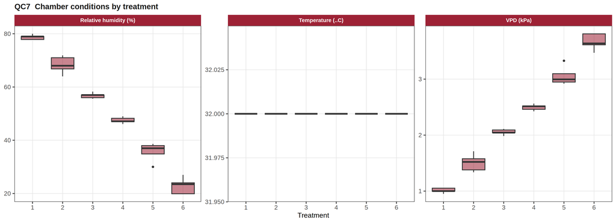

Fig. QC7. Temperature, RH, and VPD achieved per treatment.

### QC8 - Day 1 vs Day 2 TR

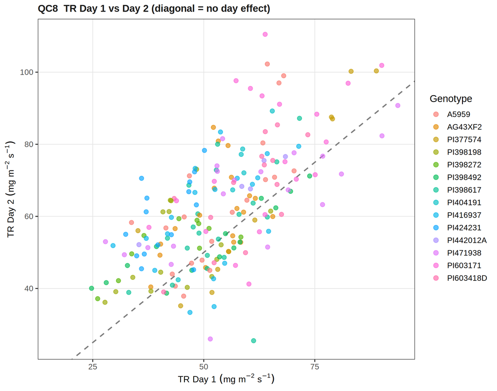

Fig. QC8. Day 1 vs Day 2 TR. Points near the diagonal indicate day-to-day consistency.

## Transpiration rate (TR) models

Models fitted per genotype (Day-1 data, Rep as random effect via nlme):

- **Linear**: TR = a + b·VPD
- **Bilinear**: two slopes joined at a breakpoint BP
- **Linear plateau**: linear increase then flat at TRₘₐₓ (classic LT response)

### Fig 1 - All models per genotype

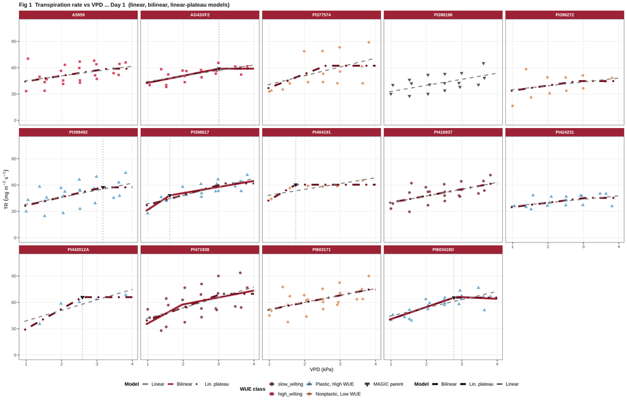

**Fig. 1.** TR vs VPD per genotype. Points coloured by WUE class. All three model curves shown; bold = best model by AIC. Inverted triangles mark estimated breakpoints.

### Fig 2 - Pooled by WUE class

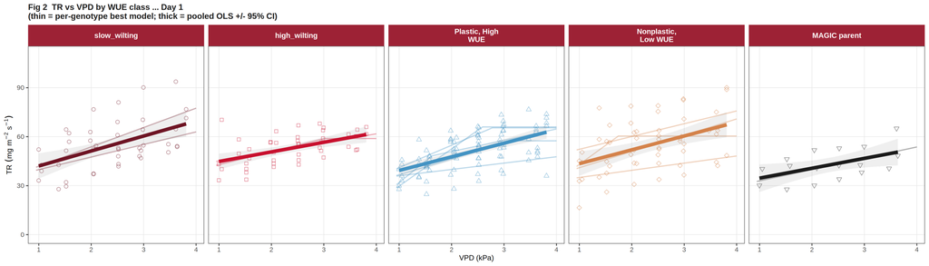

**Fig. 2.** TR vs VPD by WUE class. Thin = per-genotype best model; thick = pooled OLS ±95% CI.

### Fig 3 - Breakpoint VPD

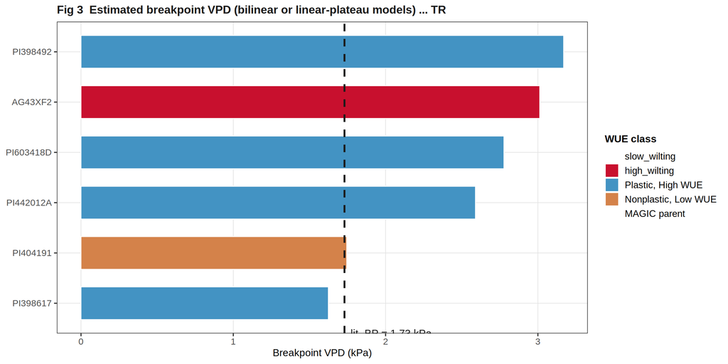

**Fig. 3.** Estimated breakpoint VPD for genotypes with non-linear best model. Dashed line at 1.73 kPa (literature LT breakpoint).

### Fig 4 - Transpiration sensitivity (Slope₁)

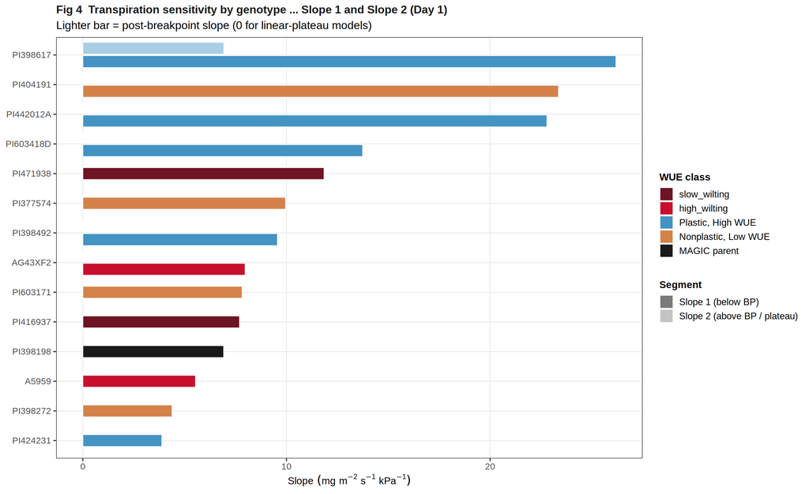

**Fig. 4.** Initial slope of TR vs VPD per genotype. Higher = greater sensitivity to VPD in the linear range.

### Fig 4 - Slope 1 and Slope 2 by genotype

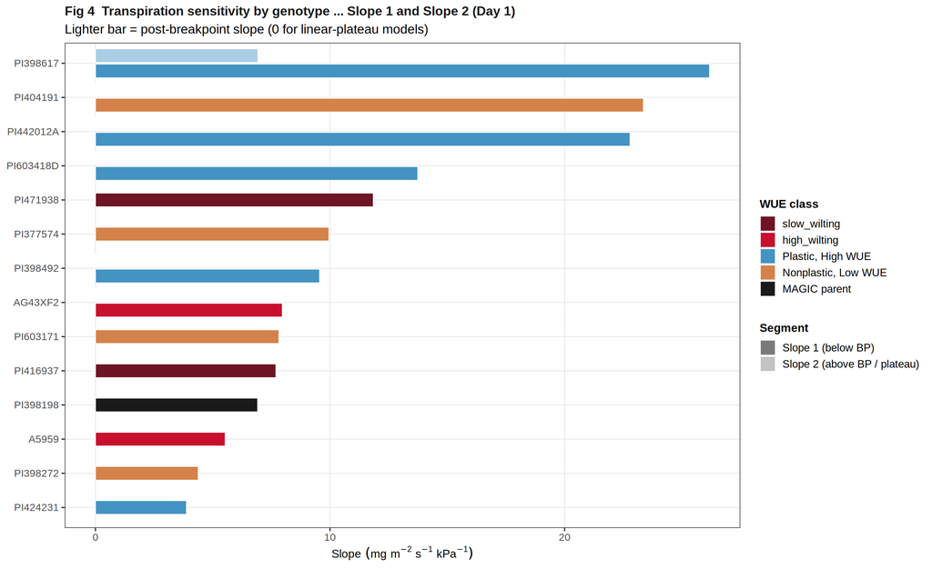

**Fig. 4.** Transpiration sensitivity per genotype. Solid bars = Slope 1 (below breakpoint or full range for linear models). Lighter bars = Slope 2 (above breakpoint; 0 for linear-plateau models; absent for linear models). Genotypes ordered by Slope 1.

### Fig 9 - Intercept by genotype

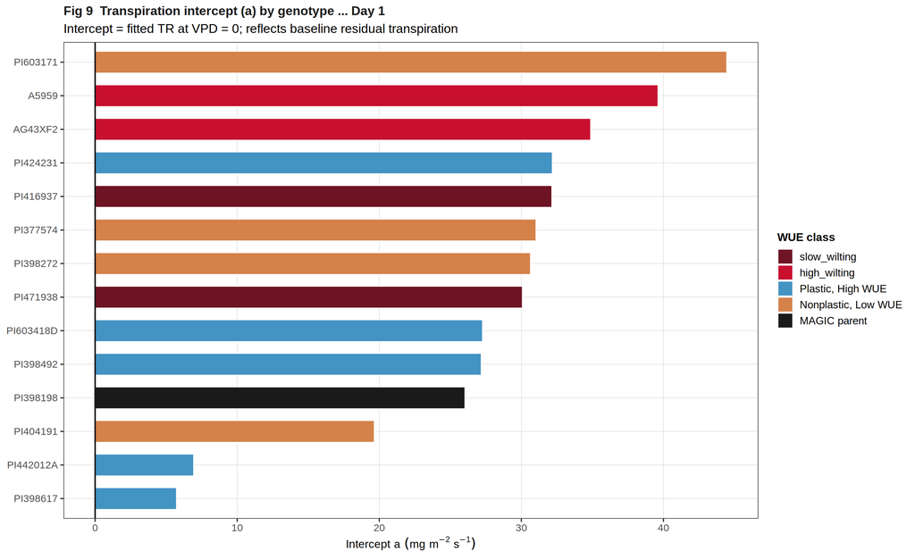

**Fig. 9.** Fitted intercept (parameter *a*) per genotype. Represents the model-predicted TR at VPD = 0, i.e., the baseline residual transpiration not driven by the vapour pressure deficit. Large positive intercepts indicate cuticular or minimum stomatal conductance operating even at near-zero VPD.

### Fig 12 - Intercept vs Slope 1 quadrant classification

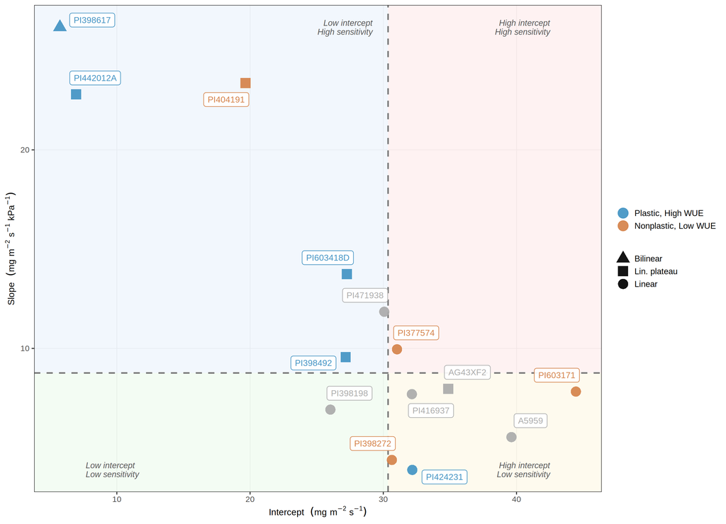

### Fig 6 - AIC model comparison

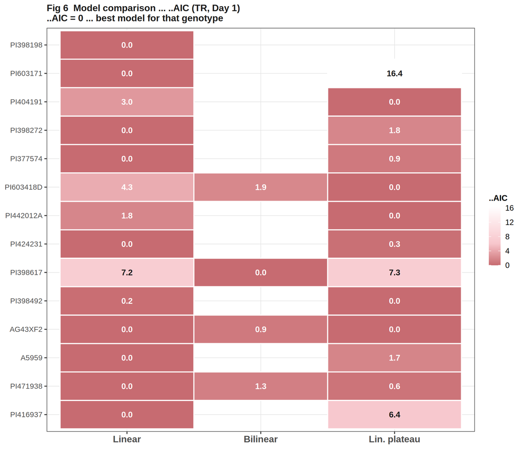

**Fig. 6.** ΔAIC heatmap. Red = best model (ΔAIC = 0).

### Fig 7 - All data points with best model

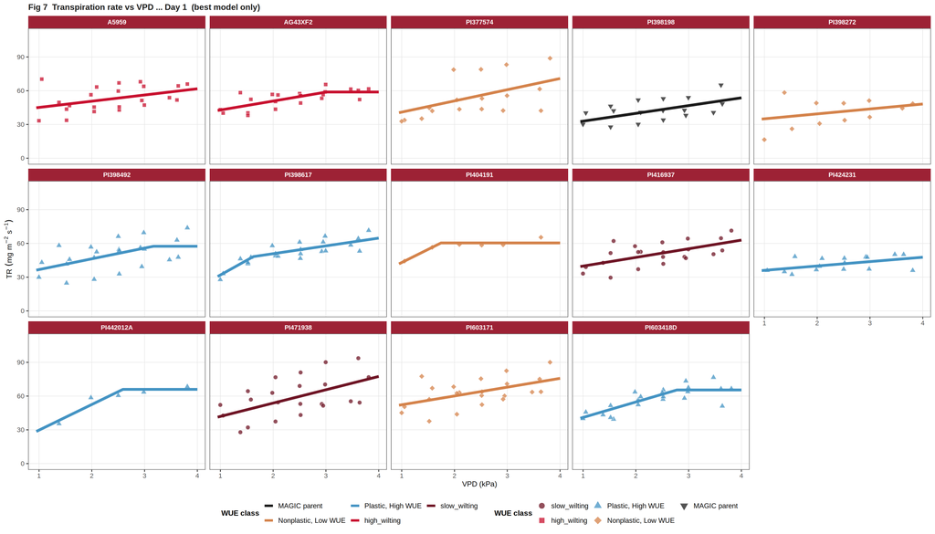

**Fig. 7.** Transpiration rate vs VPD per genotype (Day 1) — best-fit model only. All raw data points shown; curve colour matches WUE class.

## Stomatal conductance (g<sub>sw</sub>) models

### Fig 5 - g<sub>sw</sub> per genotype

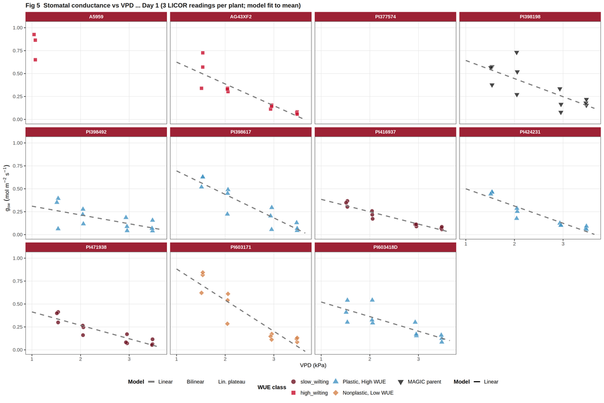

**Fig. 5.** Stomatal conductance vs VPD per genotype. Points show the three individual LICOR readings per plant; model curve fitted to the per-plant mean. Negative slopes indicate stomatal closure in response to increasing VPD.

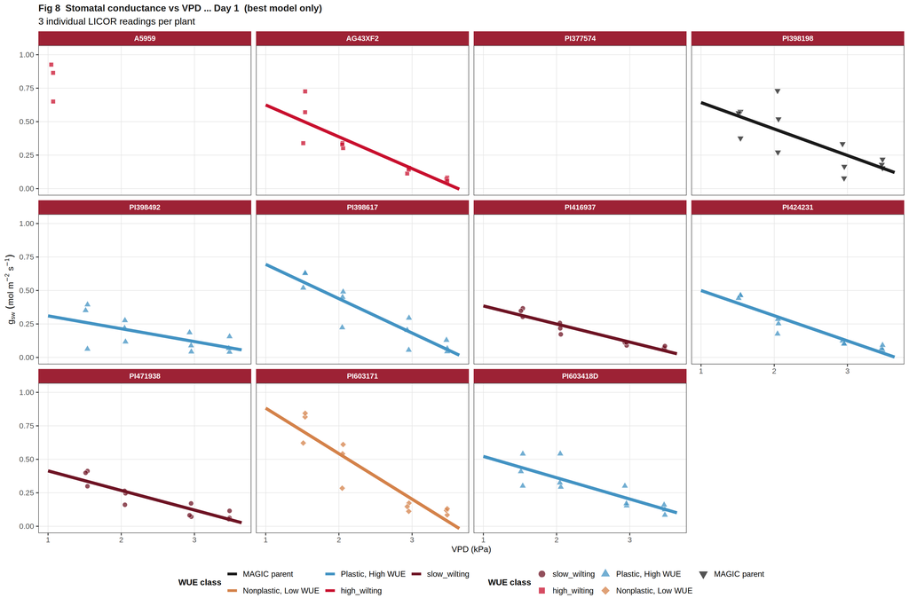

**Fig. 8.** Stomatal conductance vs VPD per genotype (Day 1) — best-fit model only. Three individual LICOR readings shown per plant per treatment; curve colour matches WUE class.

## TR vs g<sub>sw</sub> slope analysis

### Fig 11 - Predicted g<sub>sw</sub> and TR at VPD 1.5 and 3.5 kPa — individual genotypes

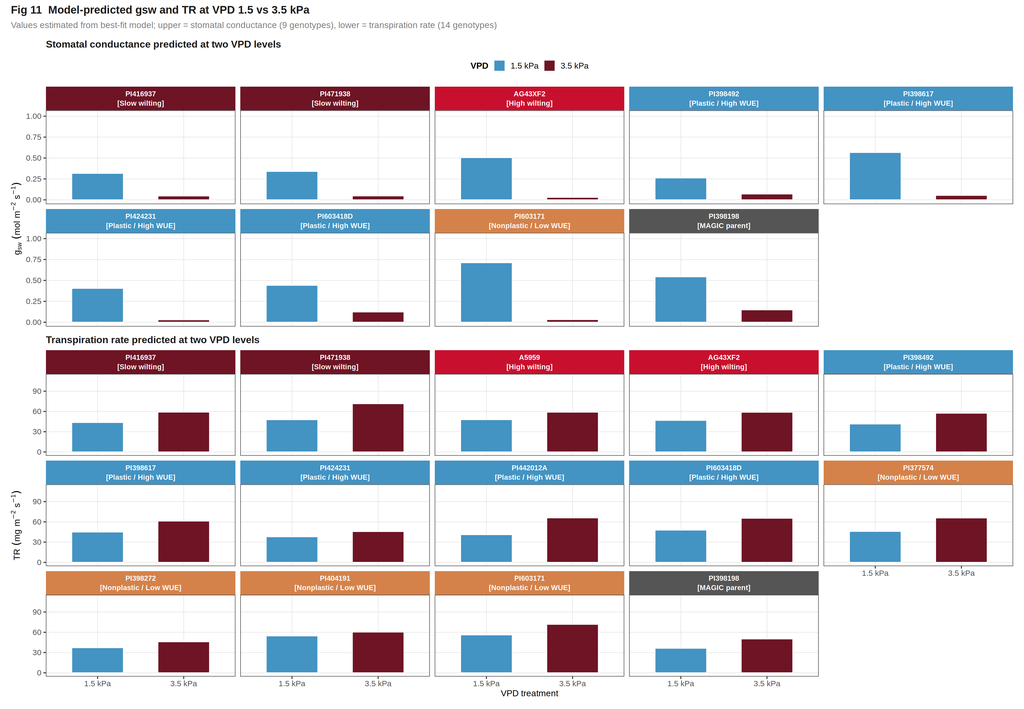

**Fig. 11.** Model-predicted stomatal conductance (upper, 9 genotypes with LICOR data) and transpiration rate (lower, 14 genotypes) at VPD 1.5 kPa (blue) and VPD 3.5 kPa (dark red) for each genotype individually. Values are extracted from each genotype’s best-fit model at the two VPD targets. A larger bar at 3.5 kPa relative to 1.5 kPa indicates continued stomatal opening under high atmospheric demand; a smaller bar indicates stomatal limitation (LT response).

### Fig 10 - TR Slope 1 vs g<sub>sw</sub> Slope 1

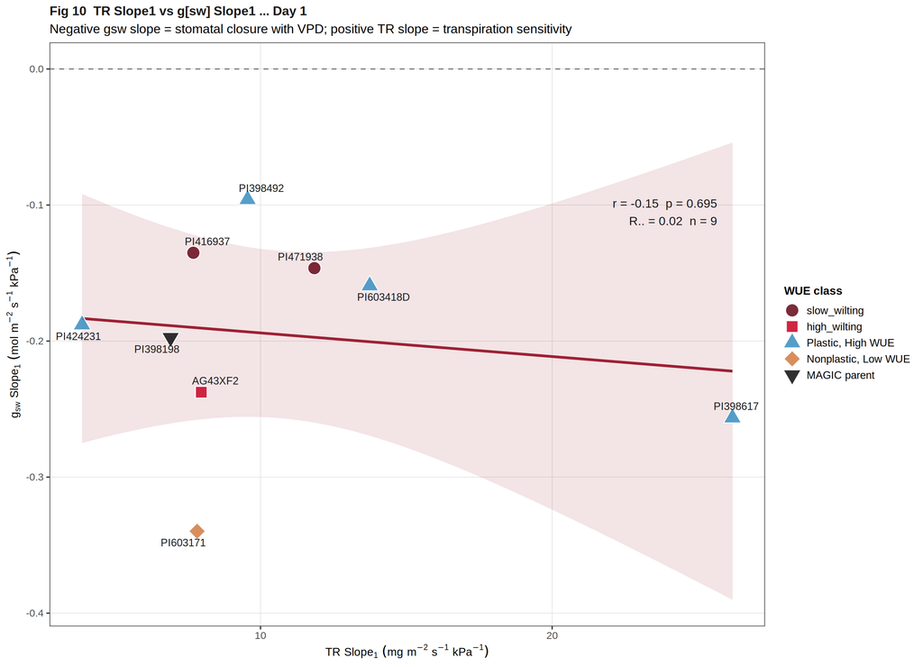

**Fig. 10.** Scatter plot of transpiration sensitivity (TR Slope 1) against stomatal closure rate (g<sub>sw</sub> Slope 1) for the 9 genotypes with both measurements. Red line = OLS regression with 95% CI band. Pearson r = -0.153, p = 0.6951, R² = 0.023.

### Critical analysis

**Key finding:** No significant linear relationship between TR Slope 1 and g<sub>sw</sub> Slope 1 (Pearson r = -0.153, p = 0.6951, R² = 0.023, n = 9).

**Physiological background.** Vapour pressure deficit (VPD) drives water loss through two pathways: (1) directly, by increasing the concentration gradient between the leaf interior and bulk air, and (2) indirectly, by triggering ABA-mediated stomatal closure that reduces g<sub>sw</sub> and therefore limits transpiration. In well-coupled canopies, stomata are the primary control: a steeper decline in g<sub>sw</sub> with VPD (more negative Slope 1) should in principle suppress the TR increase (lower TR Slope 1). The limited-transpiration (LT) trait in soybean is proposed to operate through this hydraulic-stomatal feedback, capping TR above a breakpoint VPD.

**Why the correlation is absent here.** Despite the intuitive expectation of coupling, four structural features of this dataset most likely explain the lack of correlation:

**Interpretation for the LT trait.** The absence of a TR-g<sub>sw</sub> correlation does not invalidate the LT phenotype concept. Rather, it underscores that gravimetric TR is the appropriate primary variable for quantifying the LT response, while g<sub>sw</sub> measured by LICOR in this experiment provides only qualitative, supplementary evidence. All genotypes show negative g<sub>sw</sub> slopes (stomata close as VPD rises), consistent with the general stomatal response to atmospheric demand. The magnitude of this closure, however, cannot be reliably ranked from single-plant LICOR data. A dedicated stomatal experiment (multiple replicates per genotype per VPD, same-leaf pressure-flow or porometry) would be needed to quantify the stomatal component of the LT mechanism.

## Summary tables

### Table 3 - TR best-model parameters

Intercept (a) = fitted TR at VPD = 0 (baseline residual transpiration); Slope1 = initial (below-BP) sensitivity to VPD; BP = breakpoint VPD (kPa); Slope2 = post-BP slope (bilinear only; 0 by definition for linear-plateau). - = not applicable.

Table 3. Transpiration rate - best-model parameters per genotype.

[output not shown]

### Table 4 - g<sub>sw</sub> best-model parameters

Intercept (a) = fitted g<sub>sw</sub> at VPD = 0; negative Slope1 = stomatal closure with increasing VPD. FAILED = too few valid observations to fit the model.

Table 4. Stomatal conductance - best-model parameters per genotype.

[output not shown]

### Table 5 - AIC comparison (TR)

Table 5. AIC and DeltaAIC for all three TR model types per genotype.

| Genotype | Model | AIC | DeltaAIC |
| --- | --- | --- | --- |
| A5959 | Linear | 154.9 | 0.0 |
| A5959 | Lin. plateau | 156.5 | 1.7 |
| AG43XF2 | Linear | 144.5 | 0.0 |
| AG43XF2 | Bilinear | 145.5 | 0.9 |
| AG43XF2 | Lin. plateau | 144.5 | 0.0 |
| PI377574 | Linear | 139.2 | 0.0 |
| PI377574 | Lin. plateau | 140.1 | 0.9 |
| PI398198 | Linear | 114.4 | 0.0 |
| PI398272 | Linear | 85.1 | 0.0 |
| PI398272 | Lin. plateau | 86.9 | 1.8 |
| PI398492 | Linear | 149.8 | 0.2 |
| PI398492 | Lin. plateau | 149.6 | 0.0 |
| PI398617 | Linear | 139.0 | 7.2 |
| PI398617 | Bilinear | 131.8 | 0.0 |
| PI398617 | Lin. plateau | 139.1 | 7.3 |
| PI404191 | Linear | 38.4 | 3.0 |
| PI404191 | Lin. plateau | 35.4 | 0.0 |
| PI416937 | Linear | 157.0 | 0.0 |
| PI416937 | Lin. plateau | 163.4 | 6.4 |
| PI424231 | Linear | 100.6 | 0.0 |
| PI424231 | Lin. plateau | 100.9 | 0.3 |
| PI442012A | Linear | 39.5 | 1.8 |
| PI442012A | Lin. plateau | 37.6 | 0.0 |
| PI471938 | Linear | 172.2 | 0.0 |
| PI471938 | Bilinear | 173.5 | 1.3 |
| PI471938 | Lin. plateau | 172.8 | 0.6 |
| PI603171 | Linear | 157.5 | 0.0 |
| PI603171 | Lin. plateau | 173.9 | 16.4 |
| PI603418D | Linear | 153.0 | 4.3 |
| PI603418D | Bilinear | 150.5 | 1.9 |
| PI603418D | Lin. plateau | 148.6 | 0.0 |

### Table 6 - AIC comparison (g<sub>sw</sub>)

Table 6. AIC and DeltaAIC for all three gsw model types per genotype.

| Genotype | Model | AIC | DeltaAIC |
| --- | --- | --- | --- |
| AG43XF2 | Linear | -6.4 | 0 |
| PI398198 | Linear | -4.1 | 0 |
| PI398492 | Linear | -15.5 | 0 |
| PI398617 | Linear | -9.4 | 0 |
| PI416937 | Linear | -10.8 | 0 |
| PI424231 | Linear | -5.0 | 0 |
| PI471938 | Linear | -8.8 | 0 |
| PI603171 | Linear | -2.7 | 0 |
| PI603418D | Linear | -12.3 | 0 |

### Table 7 - Genotype quadrant classification (Fig. 12)

Thresholds = median intercept and median Slope 1 across all 14 genotypes. Intercept units: mg m⁻² s⁻¹; Slope 1 units: mg m⁻² s⁻¹ kPa⁻¹.

Table 7. TR baseline vs VPD sensitivity quadrant assignment.

| Genotype | WUE class | Best model | Intercept (mg m-2 s-1) | Slope | Quadrant |
| --- | --- | --- | --- | --- | --- |
| A5959 | high_wilting | Linear | 39.62 | 5.533 | High intercept / Low sensitivity |
| AG43XF2 | high_wilting | Lin. plateau | 34.88 | 7.970 | High intercept / Low sensitivity |
| PI377574 | Nonplastic, Low WUE | Linear | 31.03 | 9.956 | High intercept / High sensitivity |
| PI398198 | MAGIC parent | Linear | 26.03 | 6.917 | Low intercept / Low sensitivity |
| PI398272 | Nonplastic, Low WUE | Linear | 30.64 | 4.384 | High intercept / Low sensitivity |
| PI398492 | Plastic, High WUE | Lin. plateau | 27.18 | 9.557 | Low intercept / High sensitivity |
| PI398617 | Plastic, High WUE | Bilinear | 5.73 | 26.181 | Low intercept / High sensitivity |
| PI404191 | Nonplastic, Low WUE | Lin. plateau | 19.65 | 23.361 | Low intercept / High sensitivity |
| PI416937 | slow_wilting | Linear | 32.15 | 7.697 | High intercept / Low sensitivity |
| PI424231 | Plastic, High WUE | Linear | 32.18 | 3.881 | High intercept / Low sensitivity |
| PI442012A | Plastic, High WUE | Lin. plateau | 6.93 | 22.794 | Low intercept / High sensitivity |
| PI471938 | slow_wilting | Linear | 30.07 | 11.847 | Low intercept / High sensitivity |
| PI603171 | Nonplastic, Low WUE | Linear | 44.46 | 7.826 | High intercept / Low sensitivity |
| PI603418D | Plastic, High WUE | Lin. plateau | 27.27 | 13.743 | Low intercept / High sensitivity |

## Data transparency: original vs clean data

The original data file is `data/data_all.xlsx` (sheet "dataAll", 491 rows × 31 columns). The cleaned file `data/data_clean.csv` differs from the original in the following documented ways:

- **Column renaming.** Technical column names were standardised for readability: `RepNo` → `Rep`, `day` → `Day`, `TR_mg_sqm_seg` → `TR`, `RelativeTransp` → `RelTR`, `avg_vpd` → `VPD`, `avg_temperature` → `Temp_C`, `avg_rh` → `RH_pct`, `LeafArea_squarecm` → `LeafArea`, `treatment_time_mins` → `duration_min`. No values were altered.
- **Derived variables added.** (a) `Day_label`: factor "Day 1" / "Day 2" derived from the numeric `Day` column. (b) `gsw`: row-mean of the three LICOR stomatal conductance readings (`gsw1`, `gsw2`, `gsw3`); set to NA when all three readings are missing.
- **Outlier flag added (not removed).** A column `TR_outlier` (logical) was computed using the 3×IQR rule within each Genotype × Day × Treatment group. No observations were excluded; the flag is retained for downstream filtering if needed. Zero outliers were detected.
- **Empty trailing column removed.** The raw Excel file contains one entirely-NA column (column 31) introduced by Excel formatting. It was dropped during import.
- **Factor encoding.** `Rep`, `Genotype`, `WUE_class`, and `Treatment` were encoded as ordered factors (with `WUE_class` following the biological order: slow wilting → high wilting → Plastic High WUE → Nonplastic Low WUE → MAGIC parent).
- **No imputation or value modification.** All original measurements are preserved exactly. The 10 rows with missing TR / VPD values remain in the clean file and are excluded only at the model-fitting stage via `na.omit()`.

## Methods summary

### Data

Source: `data/data_all.xlsx` (sheet "dataAll"). 491 observations, 14 genotypes, 4 replicates, 2 days, 6 VPD treatments. TR (mg m⁻² s⁻¹) = (Initial − Final weight) × 1000 / (leaf area m² × duration s).

### Model fitting

Day-1 data only. Random effect: Rep (replicate) fitted via `nlme::lme()` for the linear model and `nlme::nlme()` for bilinear and linear-plateau models (nls fallback when nlme fails to converge). Model selection by AIC.

### Scripts

- `script/01_data_inspection_QC.R` — data loading, QC, diagnostic figures
- `script/02_model_fitting_TR_gs_VPD.R` — model fitting, publication figures, parameter tables
- `script/03_generate_report.R` — this HTML report